# Storm Consequences on Health and Economics in the US

## Synopsis

Storms and other severe weather events can cause significant impact to both population health and economies. Preventing and mitigating said impacts is a matter of public concern.

The following analysis aims to help determine the main causes of population health and economic problems in relation to severe weather events so that priorities can be established.

The data used for this analysis was taken from the U.S. National Oceanic and Atmospheric Administration’s (NOAA) storm database. The events in the database start in the year 1950 and end in November 2011.

## Data Processing

### Libraries needed for the analysis

```r
library(dplyr)
```

```r
library(ggplot2)
library(stringr)
```

### Loading the data

The data is loaded from here: [Storm Data](https://d396qusza40orc.cloudfront.net/repdata%2Fdata%2FStormData.csv.bz2) and is in the BZ2 compressed format.

The file was downloaded using the CURL method.The data was read as a CSV directly into a variable.

```r
download.file(url = "https://d396qusza40orc.cloudfront.net/repdata%2Fdata%2FStormData.csv.bz2", destfile = "StormData.csv.bz2", method = "curl")
data.raw <- read.csv("StormData.csv.bz2")
```

### Processing the data

Since the purpose of this study is to analise the economic and health impact of the storm events there is no need to include rows that have 0 impact in all damage and human cost related columns.

The correct type needs to be set for each column:

- EVTYPE: factor
- PROPDMG: numeric
- PROPDMGEXP: factor
- CROPDMG: numeric
- CROPDMGEXP: factor
- INJURIES: numeric
- FATALITIES: numeric

All other columns were not needed for this analysis and were dropped.

```r
data.processed <-
    data.raw[!(data.raw$PROPDMG == 0 & data.raw$CROPDMG == 0 & data.raw$INJURIES == 0 & data.raw$FATALITIES == 0), ] %>%
    select(EVTYPE, PROPDMG, PROPDMGEXP, CROPDMG, CROPDMGEXP, INJURIES, FATALITIES) %>%
    mutate(
        EVTYPE = toupper(str_trim(EVTYPE)),
        PROPDMG = as.numeric(PROPDMG),
        PROPDMGEXP = as.factor(toupper(PROPDMGEXP)),
        CROPDMG = as.numeric(CROPDMG),
        CROPDMGEXP = as.factor(toupper(CROPDMGEXP)),
        INJURIES = as.numeric(INJURIES),
        FATALITIES = as.numeric(FATALITIES))
```

The event types are not consistent - some events are the same even though they have different names. The event types were therefore trimmed, uppercase and normalized for consistency. Additionally, typos were corrected.

Event types were aggregated into common groups (with the same characteristics) to make the analysis as accurate as possible.

```r
## these are obviously typos
data.processed$EVTYPE[data.processed$EVTYPE == "DRY MIRCOBURST WINDS"] <- "DRY MICROBURST WINDS"
data.processed$EVTYPE[data.processed$EVTYPE == "WET MICOBURST"] <- "WET MICROBURST"
data.processed$EVTYPE[data.processed$EVTYPE == "TORNDAO"] <- "TORNADO"
data.processed$EVTYPE[data.processed$EVTYPE == "AVALANCE"] <- "AVALANCHE"

## all these variants are LIGHTNING
data.processed$EVTYPE[data.processed$EVTYPE == "LIGHTING"] <- "LIGHTNING"
data.processed$EVTYPE[data.processed$EVTYPE == "LIGNTNING"] <- "LIGHTNING"
data.processed$EVTYPE[data.processed$EVTYPE == "LIGHTING"] <- "LIGHTNING"
data.processed$EVTYPE[data.processed$EVTYPE == "LIGHTNING."] <- "LIGHTNING"
data.processed$EVTYPE[data.processed$EVTYPE == "LIGHTNING INJURY"] <- "LIGHTNING"
data.processed$EVTYPE[data.processed$EVTYPE == "LIGHTNING FIRE"] <- "LIGHTNING"
data.processed$EVTYPE[data.processed$EVTYPE == "LIGHTNING  WAUSEON"] <- "LIGHTNING"
data.processed$EVTYPE[data.processed$EVTYPE == "LIGHTNING  WAUSEON"] <- "LIGHTNING"

## these variants are all THUNDERSTORM WIND
data.processed$EVTYPE[data.processed$EVTYPE == "THUNDERSTORM WINS"] <- "THUNDERSTORM WIND"
data.processed$EVTYPE[data.processed$EVTYPE == "THUNDERESTORM WINDS"] <- "THUNDERSTORM WIND"
data.processed$EVTYPE[data.processed$EVTYPE == "THUNDEERSTORM WINDS"] <- "THUNDERSTORM WIND"
data.processed$EVTYPE[data.processed$EVTYPE == "THUNDERSTORM WIND."] <- "THUNDERSTORM WIND"
data.processed$EVTYPE[data.processed$EVTYPE == "THUNDERSTORM WINDS."] <- "THUNDERSTORM WIND"

## better to uniformize the word windchill
data.processed$EVTYPE[data.processed$EVTYPE == "EXTREME WIND CHILL"] <- "EXTREME WINDCHILL"
data.processed$EVTYPE[data.processed$EVTYPE == "EXTREME WIND CHILLs"] <- "EXTREME WINDCHILLs"

## better to uniformize the word waterspout
data.processed$EVTYPE[data.processed$EVTYPE == "WATER SPOUT"] <- "WATERSPOUT"
data.processed$EVTYPE[data.processed$EVTYPE == "WATERSPOUT-"] <- "WATERSPOUT"

## all these variants are FLASH FLOOD
data.processed$EVTYPE[data.processed$EVTYPE == "FLOOD/FLASH FLOOD"] <- "FLASH FLOOD"
data.processed$EVTYPE[data.processed$EVTYPE == "FLOOD/FLASH"] <- "FLASH FLOOD"
data.processed$EVTYPE[data.processed$EVTYPE == "FLASH FLOOD/"] <- "FLASH FLOOD"
data.processed$EVTYPE[data.processed$EVTYPE == "FLOOD FLASH"] <- "FLASH FLOOD"
data.processed$EVTYPE[data.processed$EVTYPE == "FLASH FLOOD/FLOOD"] <- "FLASH FLOOD"
data.processed$EVTYPE[data.processed$EVTYPE == "FLOOD/FLASHFLOOD"] <- "FLASH FLOOD"
data.processed$EVTYPE[data.processed$EVTYPE == "FLOOD/FLASH/FLOOD"] <- "FLASH FLOOD"
data.processed$EVTYPE[data.processed$EVTYPE == "FLASH FLOODING"] <- "FLASH FLOOD"
data.processed$EVTYPE[data.processed$EVTYPE == "FLASH FLOODING/FLOOD"] <- "FLASH FLOOD"
data.processed$EVTYPE[data.processed$EVTYPE == "FLASH FLOODS"] <- "FLASH FLOOD"
data.processed$EVTYPE[data.processed$EVTYPE == "FLASH FLOOD FROM ICE JAMS"] <- "FLASH FLOOD"
data.processed$EVTYPE[data.processed$EVTYPE == "FLASH FLOOD - HEAVY RAIN"] <- "FLASH FLOOD"
data.processed$EVTYPE[data.processed$EVTYPE == "FLASH FLOOD WINDS"] <- "FLASH FLOOD"
data.processed$EVTYPE[data.processed$EVTYPE == "FLASH FLOOD/ STREET"] <- "FLASH FLOOD"
data.processed$EVTYPE[data.processed$EVTYPE == "FLASH FLOOD/LANDSLIDE"] <- "FLASH FLOOD"

## all these variants are FLOOD
data.processed$EVTYPE[data.processed$EVTYPE == "FLOOD & HEAVY RAIN"] <- "FLOOD"
data.processed$EVTYPE[data.processed$EVTYPE == "FLOODING"] <- "FLOOD"
data.processed$EVTYPE[data.processed$EVTYPE == "URBAN AND SMALL STREAM FLOODIN"] <- "FLOOD"
data.processed$EVTYPE[data.processed$EVTYPE == "URBAN/SML STREAM FLD"] <- "FLOOD"
data.processed$EVTYPE[data.processed$EVTYPE == "MAJOR FLOOD"] <- "FLOOD"
data.processed$EVTYPE[data.processed$EVTYPE == "FLOOD/RAIN/WINDS"] <- "FLOOD"
data.processed$EVTYPE[data.processed$EVTYPE == "BREAKUP FLOODING"] <- "FLOOD"
data.processed$EVTYPE[data.processed$EVTYPE == "FLOOD/RAIN/WINDS"] <- "FLOOD"
data.processed$EVTYPE[data.processed$EVTYPE == "FLOODS"] <- "FLOOD"
data.processed$EVTYPE[data.processed$EVTYPE == "HEAVY RAIN AND FLOOD"] <- "FLOOD"
data.processed$EVTYPE[data.processed$EVTYPE == "HEAVY RAINS/FLOODING"] <- "FLOOD"
data.processed$EVTYPE[data.processed$EVTYPE == "ICE JAM FLOOD (MINOR"] <- "FLOOD"
data.processed$EVTYPE[data.processed$EVTYPE == "ICE JAM FLOODING"] <- "FLOOD"
data.processed$EVTYPE[data.processed$EVTYPE == "MAJOR FLOOD"] <- "FLOOD"
data.processed$EVTYPE[data.processed$EVTYPE == "MINOR FLOODING"] <- "FLOOD"
data.processed$EVTYPE[data.processed$EVTYPE == "RURAL FLOOD"] <- "FLOOD"
data.processed$EVTYPE[data.processed$EVTYPE == "SMALL STREAM FLOOD"] <- "FLOOD"
data.processed$EVTYPE[data.processed$EVTYPE == "SNOWMELT FLOODING"] <- "FLOOD"
data.processed$EVTYPE[data.processed$EVTYPE == "URBAN AND SMALL"] <- "FLOOD"
data.processed$EVTYPE[data.processed$EVTYPE == "URBAN FLOOD"] <- "FLOOD"
data.processed$EVTYPE[data.processed$EVTYPE == "URBAN FLOODING"] <- "FLOOD"
data.processed$EVTYPE[data.processed$EVTYPE == "URBAN FLOODS"] <- "FLOOD"
data.processed$EVTYPE[data.processed$EVTYPE == "URBAN SMALL"] <- "FLOOD"
data.processed$EVTYPE[data.processed$EVTYPE == "URBAN/SMALL STREAM"] <- "FLOOD"
data.processed$EVTYPE[data.processed$EVTYPE == "URBAN/SMALL STREAM FLOOD"] <- "FLOOD"

## all these variants are RIVER FLOOD
data.processed$EVTYPE[data.processed$EVTYPE == "RIVER FLOOD"] <- "RIVER FLOOD"
data.processed$EVTYPE[data.processed$EVTYPE == "RIVER FLOODING"] <- "RIVER FLOOD"
data.processed$EVTYPE[data.processed$EVTYPE == "FLOOD/RIVER FLOOD"] <- "RIVER FLOOD"
data.processed$EVTYPE[data.processed$EVTYPE == "RIVER AND STREAM FLOOD"] <- "RIVER FLOOD"

## all these variants are LAKE FLOOD
data.processed$EVTYPE[data.processed$EVTYPE == "LAKESHORE FLOOD"] <- "LAKE FLOOD"

## all these variants are COASTAL FLOOD
data.processed$EVTYPE[data.processed$EVTYPE == "COASTAL FLOODING"] <- "COASTAL FLOOD"
data.processed$EVTYPE[data.processed$EVTYPE == "COASTAL FLOODING/EROSION"] <- "COASTAL FLOOD"
data.processed$EVTYPE[data.processed$EVTYPE == "COASTAL  FLOODING/EROSION"] <- "COASTAL FLOOD"
data.processed$EVTYPE[data.processed$EVTYPE == "EROSION/CSTL FLOOD"] <- "COASTAL FLOOD"
data.processed$EVTYPE[data.processed$EVTYPE == "HEAVY SURF COASTAL FLOODING"] <- "COASTAL FLOOD"
```

```r
## all these variants are FROST/FREEZE
data.processed$EVTYPE[data.processed$EVTYPE == "FROST\\FREEZE"] <- "FROST/FREEZE"
data.processed$EVTYPE[data.processed$EVTYPE == "FREEZE"] <- "FROST/FREEZE"
data.processed$EVTYPE[data.processed$EVTYPE == "FROST"] <- "FROST/FREEZE"
data.processed$EVTYPE[data.processed$EVTYPE == "EARLY FROST"] <- "FROST/FREEZE"
data.processed$EVTYPE[data.processed$EVTYPE == "DAMAGING FREEZE"] <- "FROST/FREEZE"
data.processed$EVTYPE[data.processed$EVTYPE == "AGRICULTURAL FREEZE"] <- "FROST/FREEZE"
data.processed$EVTYPE[data.processed$EVTYPE == "HARD FREEZE"] <- "FROST/FREEZE"
data.processed$EVTYPE[data.processed$EVTYPE == "FREEZING RAIN"] <- "FROST/FREEZE"
data.processed$EVTYPE[data.processed$EVTYPE == "FREEZING RAIN/SNOW"] <- "FROST/FREEZE"
data.processed$EVTYPE[data.processed$EVTYPE == "HARD FREEZE"] <- "FROST/FREEZE"
data.processed$EVTYPE[data.processed$EVTYPE == "LIGHT FREEZING RAIN"] <- "FROST/FREEZE"

## all these variants are SLEET
data.processed$EVTYPE[data.processed$EVTYPE == "FREEZING RAIN/SLEET"] <- "SLEET"

## all these variants are FUNNEL CLOUD
data.processed$EVTYPE[data.processed$EVTYPE == "FUNNEL CLOUD."] <- "FUNNEL CLOUD"

## all these variants are WIND
data.processed$EVTYPE[data.processed$EVTYPE == "GUSTY WINDS"] <- "WIND"
data.processed$EVTYPE[data.processed$EVTYPE == "WIND AND WAVE"] <- "WIND"
data.processed$EVTYPE[data.processed$EVTYPE == "WIND DAMAGE"] <- "WIND"
data.processed$EVTYPE[data.processed$EVTYPE == "WIND STORM"] <- "WIND"
data.processed$EVTYPE[data.processed$EVTYPE == "WIND/HAIL"] <- "WIND"
data.processed$EVTYPE[data.processed$EVTYPE == "WINDS"] <- "WIND"

## all these variants are HAIL with size
data.processed$EVTYPE[data.processed$EVTYPE == "HAIL 1.75)"] <- "HAIL"
data.processed$EVTYPE[data.processed$EVTYPE == "HAIL(0.75)"] <- "HAIL"
data.processed$EVTYPE[data.processed$EVTYPE == "SMALL HAIL"] <- "HAIL"
data.processed$EVTYPE[data.processed$EVTYPE == "HAIL 0.75"] <- "HAIL"
data.processed$EVTYPE[data.processed$EVTYPE == "HAIL 075"] <- "HAIL"
data.processed$EVTYPE[data.processed$EVTYPE == "HAIL 100"] <- "HAIL"
data.processed$EVTYPE[data.processed$EVTYPE == "HAIL 125"] <- "HAIL"
data.processed$EVTYPE[data.processed$EVTYPE == "HAIL 150"] <- "HAIL"
data.processed$EVTYPE[data.processed$EVTYPE == "HAIL 175"] <- "HAIL"
data.processed$EVTYPE[data.processed$EVTYPE == "HAIL 200"] <- "HAIL"
data.processed$EVTYPE[data.processed$EVTYPE == "HAIL 275"] <- "HAIL"
data.processed$EVTYPE[data.processed$EVTYPE == "HAIL 450"] <- "HAIL"
data.processed$EVTYPE[data.processed$EVTYPE == "HAIL 75"] <- "HAIL"
data.processed$EVTYPE[data.processed$EVTYPE == "HAIL DAMAGE"] <- "HAIL"
data.processed$EVTYPE[data.processed$EVTYPE == "HAIL/WIND"] <- "HAIL"
data.processed$EVTYPE[data.processed$EVTYPE == "HAIL/WINDS"] <- "HAIL"
data.processed$EVTYPE[data.processed$EVTYPE == "HAILSTORM"] <- "HAIL"

## all these variants are BLIZZARD
data.processed$EVTYPE[data.processed$EVTYPE == "HIGH WIND/ BLIZZARD"] <- "BLIZZARD"
data.processed$EVTYPE[data.processed$EVTYPE == "HIGH WINDS/"] <- "BLIZZARD"
data.processed$EVTYPE[data.processed$EVTYPE == "GROUND BLIZZARD"] <- "BLIZZARD"

## all these variants are COASTAL STORM
data.processed$EVTYPE[data.processed$EVTYPE == "COASTALSTORM"] <- "COASTAL STORM"

## all these variants are COLD/WIND CHILL
data.processed$EVTYPE[data.processed$EVTYPE == "COLD"] <- "COLD/WIND CHILL"
data.processed$EVTYPE[data.processed$EVTYPE == "LOW TEMPERATURE"] <- "COLD/WIND CHILL"
data.processed$EVTYPE[data.processed$EVTYPE == "EXTENDED COLD"] <- "COLD/WIND CHILL"
data.processed$EVTYPE[data.processed$EVTYPE == "COLD AND SNOW"] <- "COLD/WIND CHILL"
data.processed$EVTYPE[data.processed$EVTYPE == "COLD TEMPERATURE"] <- "COLD/WIND CHILL"
data.processed$EVTYPE[data.processed$EVTYPE == "COLD WAVE"] <- "COLD/WIND CHILL"
data.processed$EVTYPE[data.processed$EVTYPE == "COLD WEATHER"] <- "COLD/WIND CHILL"
data.processed$EVTYPE[data.processed$EVTYPE == "COLD WINDS"] <- "COLD/WIND CHILL"
data.processed$EVTYPE[data.processed$EVTYPE == "UNSEASONABLY COLD"] <- "COLD/WIND CHILL"
data.processed$EVTYPE[data.processed$EVTYPE == "UNSEASONABLE COLD"] <- "COLD/WIND CHILL"

## all these variants are EXTREME COLD/WIND CHILL
data.processed$EVTYPE[data.processed$EVTYPE == "EXTREME COLD"] <- "EXTREME COLD/WIND CHILL"
data.processed$EVTYPE[data.processed$EVTYPE == "EXTREME WINDCHILL"] <- "EXTREME COLD/WIND CHILL"
data.processed$EVTYPE[data.processed$EVTYPE == "HYPOTHERMIA"] <- "EXTREME COLD/WIND CHILL"
data.processed$EVTYPE[data.processed$EVTYPE == "HYPOTHERMIA/EXPOSURE"] <- "EXTREME COLD/WIND CHILL"
data.processed$EVTYPE[data.processed$EVTYPE == "RECORD COLD"] <- "EXTREME COLD/WIND CHILL"

## all these variants are HEAT
data.processed$EVTYPE[data.processed$EVTYPE == "HEAT WAVE"] <- "HEAT"
data.processed$EVTYPE[data.processed$EVTYPE == "HEAT WAVE DROUGHT"] <- "HEAT"
data.processed$EVTYPE[data.processed$EVTYPE == "HEAT WAVES"] <- "HEAT"
data.processed$EVTYPE[data.processed$EVTYPE == "UNSEASONABLY WARM"] <- "HEAT"

## all these variants are EXTREME HEAT
data.processed$EVTYPE[data.processed$EVTYPE == "HYPERTHERMIA/EXPOSURE"] <- "EXTREME HEAT"
data.processed$EVTYPE[data.processed$EVTYPE == "RECORD HEAT"] <- "EXTREME HEAT"
data.processed$EVTYPE[data.processed$EVTYPE == "RECORD/EXCESSIVE HEAT"] <- "EXTREME HEAT"
data.processed$EVTYPE[data.processed$EVTYPE == "EXCESSIVE HEAT"] <- "EXTREME HEAT"

## all these variants are DROUGHT
data.processed$EVTYPE[data.processed$EVTYPE == "DROUGHT/EXCESSIVE HEAT"] <- "DROUGHT"

## all these variants are HEAVY RAIN
data.processed$EVTYPE[data.processed$EVTYPE == "HVY RAIN"] <- "HEAVY RAIN"
data.processed$EVTYPE[data.processed$EVTYPE == "HEAVY RAINS"] <- "HEAVY RAIN"
data.processed$EVTYPE[data.processed$EVTYPE == "HEAVY RAIN/SEVERE WEATHER"] <- "HEAVY RAIN"
data.processed$EVTYPE[data.processed$EVTYPE == "HEAVY PRECIPITATION"] <- "HEAVY RAIN"
data.processed$EVTYPE[data.processed$EVTYPE == "RAINSTORM"] <- "HEAVY RAIN"
data.processed$EVTYPE[data.processed$EVTYPE == "RECORD RAINFALL"] <- "HEAVY RAIN"
data.processed$EVTYPE[data.processed$EVTYPE == "UNSEASONAL RAIN"] <- "HEAVY RAIN"
```

```r
## all these variants are HEAVY SNOW
data.processed$EVTYPE[data.processed$EVTYPE == "HEAVY SNOW AND HIGH WINDS"] <- "HEAVY SNOW"
data.processed$EVTYPE[data.processed$EVTYPE == "HEAVY SNOW SHOWER"] <- "HEAVY SNOW"
data.processed$EVTYPE[data.processed$EVTYPE == "HEAVY SNOW/ICE"] <- "HEAVY SNOW"
data.processed$EVTYPE[data.processed$EVTYPE == "RECORD SNOW"] <- "HEAVY SNOW"
data.processed$EVTYPE[data.processed$EVTYPE == "SNOW AND HEAVY SNOW"] <- "HEAVY SNOW"
data.processed$EVTYPE[data.processed$EVTYPE == "SNOW/HEAVY SNOW"] <- "HEAVY SNOW"

## all these variants are SNOW
data.processed$EVTYPE[data.processed$EVTYPE == "LATE SEASON SNOW"] <- "SNOW"
data.processed$EVTYPE[data.processed$EVTYPE == "LIGHT SNOW"] <- "SNOW"
data.processed$EVTYPE[data.processed$EVTYPE == "LIGHT SNOWFALL"] <- "SNOW"
data.processed$EVTYPE[data.processed$EVTYPE == "SNOW ACCUMULATION"] <- "SNOW"
data.processed$EVTYPE[data.processed$EVTYPE == "SNOW AND ICE STORM"] <- "SNOW"
data.processed$EVTYPE[data.processed$EVTYPE == "SNOW AND ICE"] <- "SNOW"
data.processed$EVTYPE[data.processed$EVTYPE == "SNOW/ ICE"] <- "SNOW"
data.processed$EVTYPE[data.processed$EVTYPE == "SNOW/BLOWING SNOW"] <- "SNOW"
data.processed$EVTYPE[data.processed$EVTYPE == "SNOW/ICE"] <- "SNOW"
data.processed$EVTYPE[data.processed$EVTYPE == "SNOW/ICE STORM"] <- "SNOW"


## all these variants are LAKE-EFFECT SNOW
data.processed$EVTYPE[data.processed$EVTYPE == "LAKE EFFECT SNOW"] <- "LAKE-EFFECT SNOW"

## all these variants are HEAVY SURF
data.processed$EVTYPE[data.processed$EVTYPE == "HEAVY SURF AND WIND"] <- "HEAVY SURF"
data.processed$EVTYPE[data.processed$EVTYPE == "HEAVY SURF/HIGH SURF"] <- "HEAVY SURF"
data.processed$EVTYPE[data.processed$EVTYPE == "ROUGH SURF"] <- "HEAVY SURF"
data.processed$EVTYPE[data.processed$EVTYPE == "HIGH SURF"] <- "HEAVY SURF"
data.processed$EVTYPE[data.processed$EVTYPE == "HIGH SURF ADVISORY"] <- "HEAVY SURF"

## all these variants are HEAVY SWELL
data.processed$EVTYPE[data.processed$EVTYPE == "HIGH SWELLS"] <- "HEAVY SWELL"
data.processed$EVTYPE[data.processed$EVTYPE == "HEAVY SWELLS"] <- "HEAVY SWELL"

## all these variants are RIP CURRENT
data.processed$EVTYPE[data.processed$EVTYPE == "RIP CURRENTS"] <- "RIP CURRENT"
data.processed$EVTYPE[data.processed$EVTYPE == "RIP CURRENTS/HEAVY SURF"] <- "RIP CURRENT"

## all these variants are ICE
data.processed$EVTYPE[data.processed$EVTYPE == "ICE ON ROAD"] <- "ICE"
data.processed$EVTYPE[data.processed$EVTYPE == "ICE ROADS"] <- "ICE"
data.processed$EVTYPE[data.processed$EVTYPE == "ICY ROADS"] <- "ICE"
data.processed$EVTYPE[data.processed$EVTYPE == "ICE FLOES"] <- "ICE"
data.processed$EVTYPE[data.processed$EVTYPE == "ICE JAM"] <- "ICE"
data.processed$EVTYPE[data.processed$EVTYPE == "ICE STORM"] <- "ICE"
data.processed$EVTYPE[data.processed$EVTYPE == "ICE/STRONG WINDS"] <- "ICE"

## all these variants are SNOW SQUALL
data.processed$EVTYPE[data.processed$EVTYPE == "SNOW SQUALLS"] <- "SNOW SQUALL"
data.processed$EVTYPE[data.processed$EVTYPE == "HEAVY SNOW SQUALLS"] <- "SNOW SQUALL"
data.processed$EVTYPE[data.processed$EVTYPE == "HEAVY SNOW/SQUALLS"] <- "SNOW SQUALL"
data.processed$EVTYPE[data.processed$EVTYPE == "HEAVY SNOW-SQUALLS"] <- "SNOW SQUALL"

## all these variants are STRONG WIND
data.processed$EVTYPE[data.processed$EVTYPE == "STRONG WINDS"] <- "STRONG WIND"
data.processed$EVTYPE[data.processed$EVTYPE == "HIGH WIND"] <- "STRONG WIND"
data.processed$EVTYPE[data.processed$EVTYPE == "HIGH WIND (G40)"] <- "STRONG WIND"
data.processed$EVTYPE[data.processed$EVTYPE == "HIGH WIND 48"] <- "STRONG WIND"
data.processed$EVTYPE[data.processed$EVTYPE == "HIGH WIND AND SEAS"] <- "STRONG WIND"
data.processed$EVTYPE[data.processed$EVTYPE == "HIGH WIND DAMAGE"] <- "STRONG WIND"
data.processed$EVTYPE[data.processed$EVTYPE == "HIGH WIND/SEAS"] <- "STRONG WIND"
data.processed$EVTYPE[data.processed$EVTYPE == "HIGH WINDS"] <- "STRONG WIND"

## all these variants are STORM SURGE
data.processed$EVTYPE[data.processed$EVTYPE == "STORM SURGE/TIDE"] <- "STORM SURGE"

## all these variants are LANDSLIDE
data.processed$EVTYPE[data.processed$EVTYPE == "LANDSLIDES"] <- "LANDSLIDE"
data.processed$EVTYPE[data.processed$EVTYPE == "FLASH FLOOD LANDSLIDES"] <- "LANDSLIDE"

## all these variants are MUDSLIDE
data.processed$EVTYPE[data.processed$EVTYPE == "MUDSLIDES"] <- "MUDSLIDE"
data.processed$EVTYPE[data.processed$EVTYPE == "MUD SLIDE"] <- "MUDSLIDE"
data.processed$EVTYPE[data.processed$EVTYPE == "MUD SLIDES"] <- "MUDSLIDE"

## all these variants are WILD FIRE
data.processed$EVTYPE[data.processed$EVTYPE == "WILD FIRES"] <- "WILD FIRE"
data.processed$EVTYPE[data.processed$EVTYPE == "WILD/FOREST FIRE"] <- "WILD FIRE"
data.processed$EVTYPE[data.processed$EVTYPE == "WILDFIRE"] <- "WILD FIRE"
data.processed$EVTYPE[data.processed$EVTYPE == "WILD FIRES"] <- "WILD FIRE"
data.processed$EVTYPE[data.processed$EVTYPE == "FOREST FIRES"] <- "WILD FIRE"
data.processed$EVTYPE[data.processed$EVTYPE == "GRASS FIRES"] <- "WILD FIRE"
data.processed$EVTYPE[data.processed$EVTYPE == "WILD/FOREST FIRES"] <- "WILD FIRE"
data.processed$EVTYPE[data.processed$EVTYPE == "WILDFIRES"] <- "WILD FIRE"

## all these variants are WINTER STORM
data.processed$EVTYPE[data.processed$EVTYPE == "WINTER STORM HIGH WINDS"] <- "WINTER STORM"
data.processed$EVTYPE[data.processed$EVTYPE == "WINTER STORMS"] <- "WINTER STORM"

## all these variants are WINTER WEATHER
data.processed$EVTYPE[data.processed$EVTYPE == "WINTER WEATHER MIX"] <- "WINTER WEATHER"
data.processed$EVTYPE[data.processed$EVTYPE == "WINTER WEATHER/MIX"] <- "WINTER WEATHER"
data.processed$EVTYPE[data.processed$EVTYPE == "WINTRY MIX"] <- "WINTER WHEATHER"
data.processed$EVTYPE[data.processed$EVTYPE == "WINTERY MIX"] <- "WINTER WEATHER"
data.processed$EVTYPE[data.processed$EVTYPE == "WINTER WHEATHER"] <- "WINTER WEATHER"

## all these variants are MARINE THUNDERSTORM WIND
data.processed$EVTYPE[data.processed$EVTYPE == "MARINE THUNDERSTORM WIND"] <- "MARINE THUNDERSTORM WIND"
data.processed$EVTYPE[data.processed$EVTYPE == "MARINE TSTM WIND"] <- "MARINE THUNDERSTORM WIND"
```

```r
## all these variants are THUNDERSTORM WIND
data.processed$EVTYPE[data.processed$EVTYPE == "THUNDERSTORM"] <- "THUNDERSTORM WIND"
data.processed$EVTYPE[data.processed$EVTYPE == "THUNDERSTORM WINDS"] <- "THUNDERSTORM WIND"
data.processed$EVTYPE[data.processed$EVTYPE == "THUNDERSTORM  WINDS"] <- "THUNDERSTORM WIND"
data.processed$EVTYPE[data.processed$EVTYPE == "THUNDERSTORM WIND (G40)"] <- "THUNDERSTORM WIND"
data.processed$EVTYPE[data.processed$EVTYPE == "THUNDERSTORM WIND G52"] <- "THUNDERSTORM WIND"
data.processed$EVTYPE[data.processed$EVTYPE == "THUNDERSTORM WINDS 13"] <- "THUNDERSTORM WIND"
data.processed$EVTYPE[data.processed$EVTYPE == "THUNDERSTORM WINDS/HAIL"] <- "THUNDERSTORM WIND"
data.processed$EVTYPE[data.processed$EVTYPE == "THUNDERSTORM WINDSS"] <- "THUNDERSTORM WIND"
data.processed$EVTYPE[data.processed$EVTYPE == "THUNDERSTORMS WINDS"] <- "THUNDERSTORM WIND"
data.processed$EVTYPE[data.processed$EVTYPE == "THUNDERSTORMW"] <- "THUNDERSTORM WIND"
data.processed$EVTYPE[data.processed$EVTYPE == "THUNDERTORM WINDS"] <- "THUNDERSTORM WIND"
data.processed$EVTYPE[data.processed$EVTYPE == "TSTM WIND"] <- "THUNDERSTORM WIND"
data.processed$EVTYPE[data.processed$EVTYPE == "TSTM WIND (G35)"] <- "THUNDERSTORM WIND"
data.processed$EVTYPE[data.processed$EVTYPE == "TSTM WIND (G40)"] <- "THUNDERSTORM WIND"
data.processed$EVTYPE[data.processed$EVTYPE == "TSTM WIND (G45)"] <- "THUNDERSTORM WIND"
data.processed$EVTYPE[data.processed$EVTYPE == "TSTM WIND/HAIL"] <- "THUNDERSTORM WIND"
data.processed$EVTYPE[data.processed$EVTYPE == "TSTM WIND  (G45)"] <- "THUNDERSTORM WIND"
data.processed$EVTYPE[data.processed$EVTYPE == "TSTM WIND (41)"] <- "THUNDERSTORM WIND"
data.processed$EVTYPE[data.processed$EVTYPE == "TSTM WIND 40"] <- "THUNDERSTORM WIND"
data.processed$EVTYPE[data.processed$EVTYPE == "TSTM WIND 45"] <- "THUNDERSTORM WIND"
data.processed$EVTYPE[data.processed$EVTYPE == "TSTM WIND 55"] <- "THUNDERSTORM WIND"
data.processed$EVTYPE[data.processed$EVTYPE == "TSTM WIND 65)"] <- "THUNDERSTORM WIND"
data.processed$EVTYPE[data.processed$EVTYPE == "TSTM WIND DAMAGE"] <- "THUNDERSTORM WIND"
data.processed$EVTYPE[data.processed$EVTYPE == "TSTM WIND G45"] <- "THUNDERSTORM WIND"
data.processed$EVTYPE[data.processed$EVTYPE == "TSTM WIND G58"] <- "THUNDERSTORM WIND"
data.processed$EVTYPE[data.processed$EVTYPE == "TSTM WINDS"] <- "THUNDERSTORM WIND"
data.processed$EVTYPE[data.processed$EVTYPE == "TSTMW"] <- "THUNDERSTORM WIND"
data.processed$EVTYPE[data.processed$EVTYPE == "TUNDERSTORM WIND"] <- "THUNDERSTORM WIND"
data.processed$EVTYPE[data.processed$EVTYPE == "SEVERE THUNDERSTORM"] <- "THUNDERSTORM WIND"
data.processed$EVTYPE[data.processed$EVTYPE == "SEVERE THUNDERSTORM WINDS"] <- "THUNDERSTORM WIND"
data.processed$EVTYPE[data.processed$EVTYPE == "SEVERE THUNDERSTORMS"] <- "THUNDERSTORM WIND"
data.processed$EVTYPE[data.processed$EVTYPE == "THUDERSTORM WINDS"] <- "THUNDERSTORM WIND"
data.processed$EVTYPE[data.processed$EVTYPE == "THUNDERSTORM DAMAGE TO"] <- "THUNDERSTORM WIND"
data.processed$EVTYPE[data.processed$EVTYPE == "THUNDERSTORM HAIL"] <- "THUNDERSTORM WIND"
data.processed$EVTYPE[data.processed$EVTYPE == "THUNDERSTORM WIND 60 MPH"] <- "THUNDERSTORM WIND"
data.processed$EVTYPE[data.processed$EVTYPE == "THUNDERSTORM WIND 65 MPH"] <- "THUNDERSTORM WIND"
data.processed$EVTYPE[data.processed$EVTYPE == "THUNDERSTORM WIND 65MPH"] <- "THUNDERSTORM WIND"
data.processed$EVTYPE[data.processed$EVTYPE == "THUNDERSTORM WIND 98 MPH"] <- "THUNDERSTORM WIND"
data.processed$EVTYPE[data.processed$EVTYPE == "THUNDERSTORM WIND G50"] <- "THUNDERSTORM WIND"
data.processed$EVTYPE[data.processed$EVTYPE == "THUNDERSTORM WIND G55"] <- "THUNDERSTORM WIND"
data.processed$EVTYPE[data.processed$EVTYPE == "THUNDERSTORM WIND G60"] <- "THUNDERSTORM WIND"
data.processed$EVTYPE[data.processed$EVTYPE == "THUNDERSTORM WIND TREES"] <- "THUNDERSTORM WIND"
data.processed$EVTYPE[data.processed$EVTYPE == "THUNDERSTORM WIND/ TREE"] <- "THUNDERSTORM WIND"
data.processed$EVTYPE[data.processed$EVTYPE == "THUNDERSTORM WIND/ TREES"] <- "THUNDERSTORM WIND"
data.processed$EVTYPE[data.processed$EVTYPE == "THUNDERSTORM WIND/AWNING"] <- "THUNDERSTORM WIND"
data.processed$EVTYPE[data.processed$EVTYPE == "THUNDERSTORM WIND/HAIL"] <- "THUNDERSTORM WIND"
data.processed$EVTYPE[data.processed$EVTYPE == "THUNDERSTORM WIND/LIGHTNING"] <- "THUNDERSTORM WIND"
data.processed$EVTYPE[data.processed$EVTYPE == "THUNDERSTORM WINDS 63 MPH"] <- "THUNDERSTORM WIND"
data.processed$EVTYPE[data.processed$EVTYPE == "THUNDERSTORM WINDS AND"] <- "THUNDERSTORM WIND"
data.processed$EVTYPE[data.processed$EVTYPE == "THUNDERSTORM WINDS G60"] <- "THUNDERSTORM WIND"
data.processed$EVTYPE[data.processed$EVTYPE == "THUNDERSTORM WINDS HAIL"] <- "THUNDERSTORM WIND"
data.processed$EVTYPE[data.processed$EVTYPE == "THUNDERSTORM WINDS LIGHTNING"] <- "THUNDERSTORM WIND"
data.processed$EVTYPE[data.processed$EVTYPE == "THUNDERSTORM WINDS/ FLOOD"] <- "THUNDERSTORM WIND"
data.processed$EVTYPE[data.processed$EVTYPE == "THUNDERSTORM WINDS/FLOODING"] <- "THUNDERSTORM WIND"
data.processed$EVTYPE[data.processed$EVTYPE == "THUNDERSTORM WINDS/FUNNEL CLOU"] <- "THUNDERSTORM WIND"
data.processed$EVTYPE[data.processed$EVTYPE == "THUNDERSTORM WINDS53"] <- "THUNDERSTORM WIND"
data.processed$EVTYPE[data.processed$EVTYPE == "THUNDERSTORM WINDSHAIL"] <- "THUNDERSTORM WIND"
data.processed$EVTYPE[data.processed$EVTYPE == "THUNDERSTORMS"] <- "THUNDERSTORM WIND"
data.processed$EVTYPE[data.processed$EVTYPE == "THUNDERSTORMS WIND"] <- "THUNDERSTORM WIND"
data.processed$EVTYPE[data.processed$EVTYPE == "THUNDERSTORMWINDS"] <- "THUNDERSTORM WIND"
data.processed$EVTYPE[data.processed$EVTYPE == "THUNDERSTROM WIND"] <- "THUNDERSTORM WIND"
data.processed$EVTYPE[data.processed$EVTYPE == "THUNERSTORM WINDS"] <- "THUNDERSTORM WIND"

## all these variants are DUST DEVIL
data.processed$EVTYPE[data.processed$EVTYPE == "DUST DEVIL WATERSPOUT"] <- "DUST DEVIL"

## all these variants are DUST STORM
data.processed$EVTYPE[data.processed$EVTYPE == "DUST STORM/HIGH WINDS"] <- "DUST STORM"
```

```r
## lumping all Hurricanes into 1 category HURRICANES
data.processed$EVTYPE[data.processed$EVTYPE == "HURRICANE-GENERATED SWELLS"] <- "HURRICANE"
data.processed$EVTYPE[data.processed$EVTYPE == "HURRICANE EDOUARD"] <- "HURRICANE"
data.processed$EVTYPE[data.processed$EVTYPE == "HURRICANE EMILY"] <- "HURRICANE"
data.processed$EVTYPE[data.processed$EVTYPE == "HURRICANE ERIN"] <- "HURRICANE"
data.processed$EVTYPE[data.processed$EVTYPE == "HURRICANE FELIX"] <- "HURRICANE"
data.processed$EVTYPE[data.processed$EVTYPE == "HURRICANE OPAL"] <- "HURRICANE"
data.processed$EVTYPE[data.processed$EVTYPE == "HURRICANE OPAL/HIGH WINDS"] <- "HURRICANE"
data.processed$EVTYPE[data.processed$EVTYPE == "HURRICANE/TYPHOON"] <- "HURRICANE"
data.processed$EVTYPE[data.processed$EVTYPE == "HURRICANE GORDON"] <- "HURRICANE"

## lumping all Tornadoes into 1 category TORNADO
data.processed$EVTYPE[data.processed$EVTYPE == "TORNADO F2"] <- "TORNADO"
data.processed$EVTYPE[data.processed$EVTYPE == "TORNADO F3"] <- "TORNADO"
data.processed$EVTYPE[data.processed$EVTYPE == "TORNADO F0"] <- "TORNADO"
data.processed$EVTYPE[data.processed$EVTYPE == "TORNADO F1"] <- "TORNADO"
data.processed$EVTYPE[data.processed$EVTYPE == "TORNADOES"] <- "TORNADO"
data.processed$EVTYPE[data.processed$EVTYPE == "WATERSPOUT TORNADO"] <- "TORNADO"
data.processed$EVTYPE[data.processed$EVTYPE == "WATERSPOUT/TORNADO"] <- "TORNADO"
data.processed$EVTYPE[data.processed$EVTYPE == "WATERSPOUT-TORNADOO"] <- "TORNADO"
data.processed$EVTYPE[data.processed$EVTYPE == "WATERSPOUT/ TORNADO"] <- "TORNADO"
data.processed$EVTYPE[data.processed$EVTYPE == "COLD AIR TORNADO"] <- "TORNADO"

## lumping all Tropical Storms into 1 category TROPICAL STORM
data.processed$EVTYPE[data.processed$EVTYPE == "TROPICAL STORM GORDON"] <- "TROPICAL STORM"
data.processed$EVTYPE[data.processed$EVTYPE == "TROPICAL STORM ALBERTO"] <- "TROPICAL STORM"
data.processed$EVTYPE[data.processed$EVTYPE == "TROPICAL STORM DEAN"] <- "TROPICAL STORM"
data.processed$EVTYPE[data.processed$EVTYPE == "TROPICAL STORM JERRY"] <- "TROPICAL STORM"

## set EVTYPE as factor
data.processed <-
    data.processed %>%
    mutate(EVTYPE = as.factor(EVTYPE))
```

The amounts related to crop and property damage are accompanied by a corresponding factor of 10. Therefore it makes sense to multiply them by 10 to the factor so we are able to summarise and compare the actual total values. For consistency, it is assumed here that both the numeric and the character values in columns PROPDMGEXP and CROPDMGEXP are factors of 10. Where the value does not make sense - for example “-”, “?” or “+” - it is assumed that the factor is 0.

After this process is done there is no need to keep the EXP columns so they were also dropped.

```r
## transform the EXP into a number so we can multiply
exp <- data.frame(
    c("", "-", "?", "+", "0", "1", "2", "3", "4", "5", "6", "7", "8", "B", "H", "K", "M"),
    c(0, 0, 0, 0, 0, 1, 2, 3, 4, 5, 6, 7, 8, 9, 2, 3, 6))

names(exp) <- c("EXP", "NUMEXP")

## merge the dataset above with the main dataset
data.processed <-
    data.processed %>%
    merge(exp, by.x = "PROPDMGEXP", by.y = "EXP") %>%
    mutate(PROPDMGEXP = NUMEXP) %>%
    select(-NUMEXP) %>%
    merge(exp, by.x = "CROPDMGEXP", by.y = "EXP") %>%
    mutate(CROPDMGEXP = NUMEXP) %>%
    select(-NUMEXP) %>%
    mutate(PROPDMG = PROPDMG * 10^PROPDMGEXP, CROPDMG = CROPDMG * 10^CROPDMGEXP, PROPDMGEXP = NULL, CROPDMGEXP = NULL)
```

A quick summary of the processed data is below.

```r
str(data.processed)
```

```
## 'data.frame':    254633 obs. of  5 variables:
##  $ EVTYPE    : Factor w/ 169 levels "?","APACHE COUNTY",..: 149 102 149 151 151 151 151 127 151 151 ...
##  $ PROPDMG   : num  1000 0 15 30 30 250 250000 0 0 450000 ...
##  $ CROPDMG   : num  0 0 0 0 0 0 0 0 0 0 ...
##  $ INJURIES  : num  0 0 0 0 0 0 10 0 5 0 ...
##  $ FATALITIES: num  0 1 0 0 0 0 0 1 2 0 ...
```

```r
summary(data.processed)
```

```
##                EVTYPE          PROPDMG             CROPDMG
##  THUNDERSTORM WIND:119673   Min.   :0.000e+00   Min.   :0.000e+00
##  TORNADO          : 39969   1st Qu.:2.000e+03   1st Qu.:0.000e+00
##  HAIL             : 26162   Median :1.000e+04   Median :0.000e+00
##  FLASH FLOOD      : 21601   Mean   :1.682e+06   Mean   :1.928e+05
##  LIGHTNING        : 13299   3rd Qu.:3.500e+04   3rd Qu.:0.000e+00
##  FLOOD            : 11205   Max.   :1.150e+11   Max.   :5.000e+09
##  (Other)          : 22724
##     INJURIES           FATALITIES
##  Min.   :   0.0000   Min.   :  0.0000
##  1st Qu.:   0.0000   1st Qu.:  0.0000
##  Median :   0.0000   Median :  0.0000
##  Mean   :   0.5519   Mean   :  0.0595
##  3rd Qu.:   0.0000   3rd Qu.:  0.0000
##  Max.   :1700.0000   Max.   :583.0000
##
```

## Analysis of population health

To address the impact of storms on population health a subset of the processed data will be used which contains only the information related to the number of fatalities and injuries caused by storm events.

Additionally, all rows which have 0 cost on both FATALITIES and INJURIES were dropped as they are irrelevant for this part of the analysis.

```r
data.populationhealth <-
    data.processed[!(data.processed$FATALITIES == 0 & data.processed$INJURIES == 0), ] %>%
    select(EVTYPE, INJURIES, FATALITIES)
```

Fatalities are generally considered to have a much higher cost in terms of population health than injuries. For this reason a weighted sum of all injuries and fatalities for each storm event type is used instead of a simple sum.

For the purpose of this study it is assumed that FATALITIES have twice the cost of INJURIES. A new column - HUMANCOST - will be created to hold the value of the sum for each event type.

```r
data.populationhealth <-
    data.populationhealth %>%
    mutate(HUMANCOST = INJURIES + 2*FATALITIES, INJURIES = NULL, FATALITIES = NULL) %>%
    group_by(EVTYPE) %>%
    summarise(HUMANCOST = sum(HUMANCOST)) %>%
    arrange(desc(HUMANCOST))
```

The following bar plot shows the distribution of the cost per event type for the top 5 results in terms of human cost. The cost has been rounded to 2 decimal points so that it can be represented in thousands.

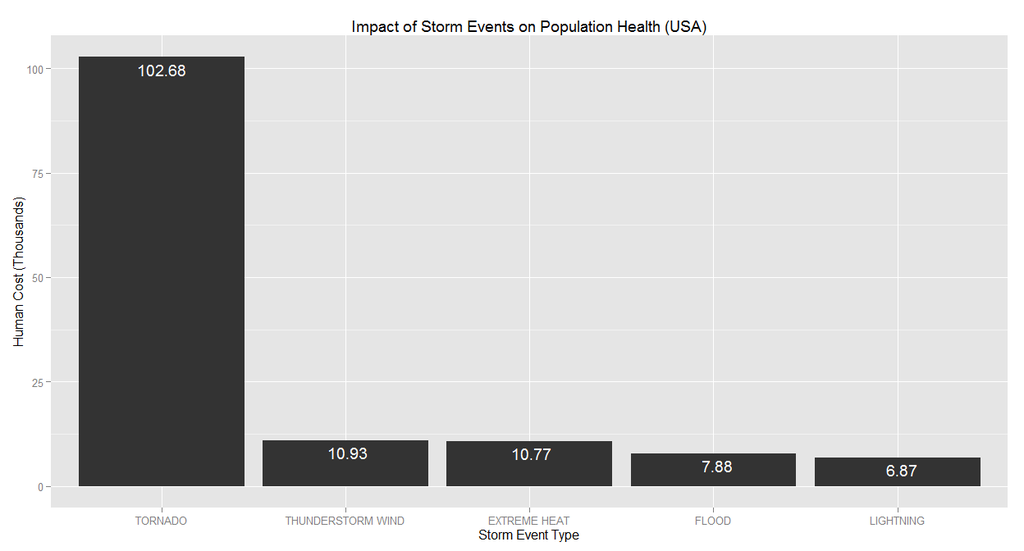

Fig 1: Top 5 most impactful storm event types on population health

```r
print(
    ggplot(
        head(data.populationhealth, n = 5),
        aes(reorder(EVTYPE, -HUMANCOST), HUMANCOST/10^3)
    ) +
    geom_bar(stat = "identity") +
    xlab("Storm Event Type") +
    ylab("Human Cost (Thousands)") +
    ggtitle("Impact of Storm Events on Population Health (USA)") +
    geom_text(aes(label = format(round(HUMANCOST/10^3, 2), nsmall = 2)),  vjust=1.5, colour = "white")
)
```

## Analysis of Economic Impact

To address the impact of storms on the economy a subset of the processed data will be used which contains only the information related to the costs of property and crop damaged caused by storm events. Additionally, all rows which have 0 cost on both PROPDMG and CROPDMG were dropped as they are irrelevant for this part of the analysis.

```r
data.economic <-
    data.processed[!(data.processed$PROPDMG == 0 & data.processed$CROPDMG == 0), ] %>%
    select(EVTYPE, PROPDMG, CROPDMG)
```

Since we are analysing the overall cost impact of the storm events in the economy, crop damage and property damage need to be added to generate the total cost. A new column - MATERIALCOST - will be created to hold the value of the sum for each event type.

```r
data.economic <-
    data.economic %>%
    mutate(MATERIALCOST = PROPDMG + CROPDMG, PROPDMG = NULL, CROPDMG = NULL) %>%
    group_by(EVTYPE) %>%
    summarise(MATERIALCOST = sum(MATERIALCOST)) %>%
    arrange(desc(MATERIALCOST))
```

The following bar plot shows the distribution of the cost per event type for the top 5 results in terms of material cost. The cost has been rounded to 2 decimal points so that it can be represented in billions.

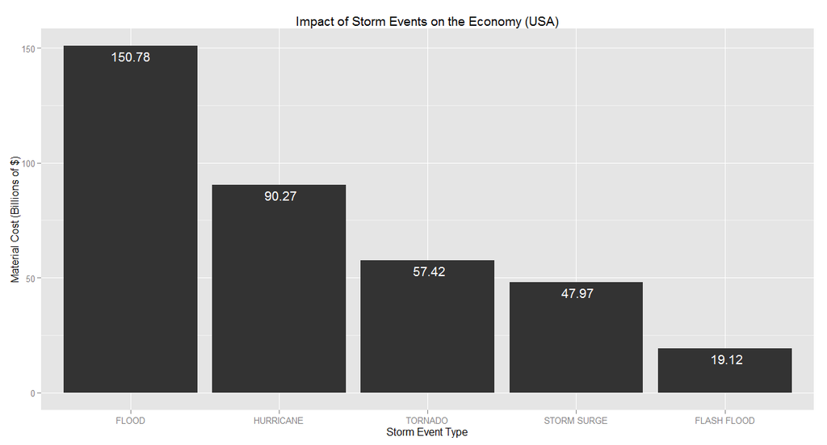

Fig 2: Top 5 most impactful storm event types on the economy

```r
print(
    ggplot(
        head(data.economic, n = 5),
        aes(reorder(EVTYPE, -MATERIALCOST), MATERIALCOST/10^9)
    ) +
    geom_bar(stat = "identity") +
    xlab("Storm Event Type") +
    ylab("Material Cost (Billions of $)") +
    ggtitle("Impact of Storm Events on the Economy (USA)") +
    geom_text(aes(label = format(round(MATERIALCOST/10^9, 2), nsmall=2)),  vjust=1.5, colour = "white")
)
```

## Results

The analysis presented in this document clearly indicates that **tornadoes** are by far the leading cause of population health issues. The second leading cause is **thunderstorm winds** but it falls behind Tornadoes by a big margin (about *92 thousand* in human cost).

When it comes to economic impact the results differ quite a bit with **floods** being the leading cause of economic losses. **Hurricanes** are a far second with a big margin (around *60 billion* USD).